# Analysis Methods for AI Evaluation

Session 6

2026-10-06

## The design sets the analysis

- Random assignment makes the difference in means an unbiased estimate.
  - Pretreatment information (blocks, pairs, covariates) can make it more precise.
- How different would it be if we ran the study again?
  - new questions
  - new users
  - new runs on the same questions
  - a new random assignment.
- Your design fixes which of these happen.
  - Uncertainty measures follow from it.

Your PAP must give the complete analysis recipe: point estimate, standard error, and confidence interval, each justified by the design.

# Where uncertainty comes from

## Every estimate comes with a margin of error

- Your study produces a number: how much changing one piece of the Bundle helps.
- Different questions, or a different coin flip for who gets which Bundle, would give a different number.
- This section asks
  - where does that variation come from?
  - how to measure it?
  - how can we conceive of and measure “correctness”?

## The running example: retrieval in a course tutor

- **System:** an LLM tutor answers course questions. **Bundle B** adds retrieval over course materials; **Bundle A** does not.
- **Sample:** $N=100$ questions drawn from the questions students could ask.
- **Assignment:** retrieval on for $m=50$ questions at random. $Z_i=1$ if question $i$ gets it.
- **Outcome:** a 0–100 score for each answer. Each question is run $R$ times; $R=1$ until stated otherwise.

$$Y_{ir}=50+\tau Z_i+a_i+e_{ir},\qquad \operatorname{sd}(a_i)=\sigma_a=8,\quad \operatorname{sd}(e_{ir})=\sigma_e=6,\quad \tau=3.$$

- $a_i$: difficulty of question $i$, shared by all its runs. $e_{ir}$: run-to-run noise.
- **Indices:** $i=1,\dots,N$ questions; $r=1,\dots,R$ runs; $NR$ scored calls.

## The difference in means and its design-based variance

- **Estimate:** mean score with retrieval minus mean score without.

$$\hat\tau=\bar Y_1-\bar Y_0,\qquad \widehat{V}(\hat\tau)=\frac{s_1^2}{m}+\frac{s_0^2}{N-m}.$$

```r
fit <- tidy(difference_in_means(Y ~ Z, data = study))
```

| Estimate | SE | Lower 95% | Upper 95% |
| --- | --- | --- | --- |
| 2.84 | 2.05 | -1.23 | 6.9 |

- The exact variance also depends on how effects vary across questions.
  - That term is unobservable, so this estimate errs on the large side.

Gerber & Green (2012), *Field Experiments*, eqs. 3.6–3.7.

## Two sources of uncertainty: sampling and assignment

Sampling

- Which questions enter the study.
- Repeat: draw new questions.
- Estimand: average effect over the **population** of questions.

Assignment

- Which questions get retrieval.
- Repeat: re-randomize the same questions.
- Estimand: average effect on **these** questions.
- The variance formula above covers both when questions are a random sample.
- A claim about new questions needs the sampling term.
  - The question set has to be a credible sample of that population.
- **Abadie et al.:** clustering is a statement about how sampling or assignment worked.

[Abadie, Athey, Imbens & Wooldridge (2023), *When Should You Adjust Standard Errors for Clustering?*, QJE 138(1).](https://arxiv.org/abs/1710.02926)

## Randomization inference

- **Sharp null:** each question scores the same with or without retrieval.
- Re-randomize the 100 questions 2,000 times; recompute the difference each time.

```r
null_diffs <- permutation_draws(study, draws = 2000)
observed <- with(study, mean(Y[Z == 1]) - mean(Y[Z == 0]))
p_value <- mean(abs(null_diffs) >= abs(observed))
```

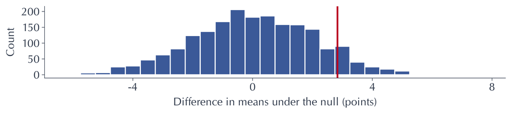

The red line is the observed difference. Two-sided $p=0.170$.

Gerber & Green (2012), *Field Experiments*, §3.4.

## Coverage is the test of a standard error

- **Coverage:** the fraction of 95% intervals containing the true effect.
- **Template:** repeat the whole design, compute each interval, count the hits.

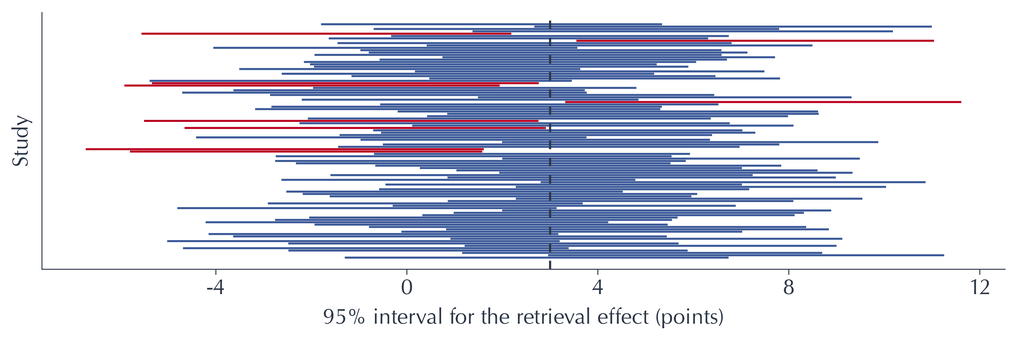

- First 100 of 250 studies. Red intervals miss the true 3-point effect.
- Coverage: 93.6%.
- Every simulation today reports coverage for a design and a standard error.

## Estimate, variance, and coverage

- Random assignment makes the **difference in means** unbiased. The **Neyman variance** gives its standard error from the design alone.
- Uncertainty has two sources: **sampling** the questions and **assigning** treatment. Which ones you count decides whether you learn about the population or about these questions.
- **Randomization inference** tests the sharp null using the assignment step alone.
- **Coverage** checks any standard error: simulate the design and see whether 95% intervals contain the truth 95% of the time.

# Matching standard errors to the design

## How to deal with repeated measures

- Eval data often reuses things:
  - the same question run many times
  - the same graders scoring every answer
- Measurements that share a question or a grader overlap in what they tell you.
- Counting each one as fresh evidence makes results look more certain than they are.
- This section provides tools to accurately reflect uncertainty

## A clustered SE sums residuals within each question

- **Mean score** over all $NR$ calls; residual $\hat e_{ir}=Y_{ir}-\bar Y$.

$$\widehat V_{\text{iid}}(\bar Y)=\frac{1}{(NR)^2}\sum_{i=1}^{N}\sum_{r=1}^{R}\hat e_{ir}^2,\qquad
\widehat V_{\text{cluster}}(\bar Y)=\frac{1}{(NR)^2}\sum_{i=1}^{N}\Big(\sum_{r=1}^{R}\hat e_{ir}\Big)^2.$$

- Expanding the square adds $\hat e_{ir}\hat e_{is}$ for every pair of runs $r\neq s$ on the same question.
  - In the model both residuals contain $a_i$, so these products average about $\sigma_a^2>0$.
  - Products across questions are set to zero: questions are the independent units.
- The approximation needs many clusters: $N$ questions, not $NR$ calls, is the sample size.

[Miller (2024), *Adding Error Bars to Evals*, eq. 4.](https://arxiv.org/abs/2411.00640)

## In regression, clustering changes the sandwich

- **Regression:** $\mathbf Y=\mathbf X\beta+\mathbf e$ by OLS. Clusters $g=1,\dots,G$ (here, questions); $\mathbf X_g$, $\hat{\mathbf e}_g$ are cluster $g$’s rows and residuals.

$$\widehat V(\hat\beta)=(\mathbf X'\mathbf X)^{-1}\Big(\sum_{g=1}^{G}\mathbf X_g'\hat{\mathbf e}_g\hat{\mathbf e}_g'\mathbf X_g\Big)(\mathbf X'\mathbf X)^{-1}.$$

- The outer terms are the OLS “bread”. The middle “meat” treats each cluster’s score $\mathbf X_g'\hat{\mathbf e}_g$ as one independent draw.
- One call per cluster: the meat is $\sum_i \mathbf x_i\mathbf x_i'\hat e_i^2$, the robust (HC0) variance.
- With $\mathbf x_i=(1,Z_i)$, the entry for $\hat\tau$ is the clustered variance of the difference in means.
- **CR2** (the `lm_robust` default): replace $\hat{\mathbf e}_g$ with $(\mathbf I_g-\mathbf H_{gg})^{-1/2}\hat{\mathbf e}_g$. $\mathbf H_{gg}$: cluster $g$’s block of $\mathbf X(\mathbf X'\mathbf X)^{-1}\mathbf X'$; $\mathbf I_g$: identity matrix.

[Bell & McCaffrey (2002), *Bias Reduction in Standard Errors for Linear Regression with Multi-Stage Samples*, Survey Methodology 28(2).](https://www150.statcan.gc.ca/n1/en/catalogue/12-001-X20020029058)

## Repeated calls are clustered within questions

- **Running example with $R=5$:** 500 scored calls on 100 questions.
- Every run of question $i$ shares $a_i$. Average the runs of each question:

$$\bar Y_i=50+\tau Z_i+a_i+\bar e_i,\qquad V(\hat\tau)=\Big(\sigma_a^2+\frac{\sigma_e^2}{R}\Big)\Big(\frac1m+\frac1{N-m}\Big).$$

- More runs shrink only the run-noise term.
- A call-level SE treats the $NR$ calls as independent.
  - It uses $(\sigma_a^2+\sigma_e^2)/R$ in place of $\sigma_a^2+\sigma_e^2/R$.
- The ratio is the **design effect**: $1+(R-1)\rho$, with $\rho=\sigma_a^2/(\sigma_a^2+\sigma_e^2)$.
  - Here $\rho=0.64$, $R=5$: variance ratio 3.6, SE ratio **1.9**.

Kish (1965), *Survey Sampling*, Wiley.

## Simulation: call-level standard errors undercover

- 100 questions; $R=1,2,5,10$ runs each; 250 studies per point.

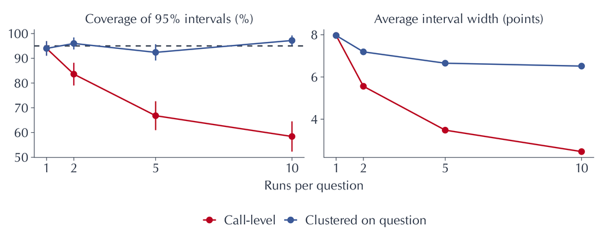

- One run per question: the two SEs coincide.
- More runs narrow the call-level interval. The clustered interval barely moves, because question difficulty dominates.

## Cluster where the design groups units

- **Abadie et al.:** the sampling process and the assignment mechanism decide whether and where to cluster.
- **Clustered assignment** (all runs of a question, a user, a classroom): cluster at the assignment level.
- **Clustered sampling** (passages, questions with repeated runs): cluster at the sampling level.
- **Neither:** questions sampled and assigned one at a time. Use robust SEs.
  - Clustering on topic widens intervals for no reason, even if scores within a topic correlate.
- **Treatment varies within sampled clusters**, as in pairs: cluster SEs are conservative.
  - The paired SE, or Abadie et al.’s CCV estimator, is tighter.
- **Miller:** clustering reading comprehension tasks by passage makes the SE **3×** larger.

[Abadie, Athey, Imbens & Wooldridge (2023), *When Should You Adjust Standard Errors for Clustering?*, QJE 138(1).](https://arxiv.org/abs/1710.02926) [Miller (2024), *Adding Error Bars to Evals*, Table 4.](https://arxiv.org/abs/2411.00640)

## Pairs and blocks: compare within, then average

- **Blocks** $j=1,\dots,J$, formed before assignment: $Y_i=50+\tau Z_i+\gamma_{j(i)}+\epsilon_i$.
  - Randomize within each block; block $j$ has $N_j$ questions, $m_j$ treated.

$$\hat\tau=\sum_{j=1}^{J}\frac{N_j}{N}\hat\tau_j,\qquad
\widehat V(\hat\tau)=\sum_{j=1}^{J}\Big(\frac{N_j}{N}\Big)^2\Big(\frac{s_{1j}^2}{m_j}+\frac{s_{0j}^2}{N_j-m_j}\Big).$$

- $\hat\tau_j$, the difference in means within block $j$, cancels the shared $\gamma_j$.
- **Pairs** are blocks of two: question $j$ runs once per Bundle, so $\hat\tau_j=D_j=Y_{jB}-Y_{jA}$.
  - One unit per arm leaves $s_{1j}^2$ undefined; use the spread of the $D_j$:

$$\widehat V(\hat\tau)=\frac{s_D^2}{J},\qquad s_D^2=s_A^2+s_B^2-2s_{AB}.$$

- Ignoring the pairs drops $s_{AB}$.

Gerber & Green (2012), *Field Experiments*, §§3.6.1, 4.4. [Miller (2024), *Adding Error Bars to Evals*, §4.2.](https://arxiv.org/abs/2411.00640)

## Simulation: ignoring pairs or blocks

- **Pairs:** both Bundles once on 100 questions. **Blocks:** lecture 05 design, 80 questions in 4 difficulty blocks.

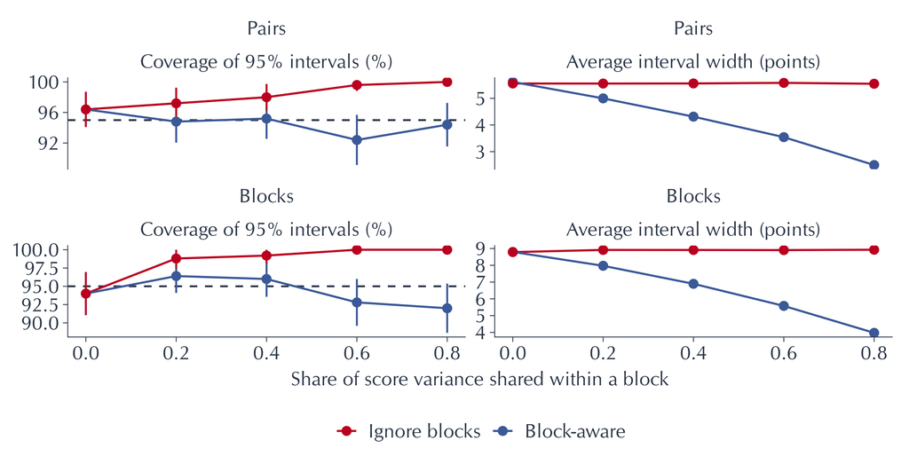

- Same $\hat\tau$ either way here. Ignoring the blocks keeps their variation in the SE: intervals stay wide.

## Questions and annotators are both sampled

- **Human-scored running example:** the same $K=20$ annotators, drawn from a pool of graders, score all $N$ answers.

$$Y_{ik}=50+\tau Z_i+a_i+b_k+\gamma_kZ_i+\varepsilon_{ik}.$$

- $a_i$: difficulty. $b_k$: leniency. $\gamma_k$: how much annotator $k$ rewards retrieval answers.
- **Target:** the effect as judged by new annotators on new questions.

$$V(\hat\tau)\approx\frac{4(\sigma_a^2+\sigma_\varepsilon^2/K)}{N}+\frac{\sigma_\gamma^2}{K}.$$

- $b_k$ cancels: every annotator scores both arms. The $\gamma_k$ term depends only on the 20 annotators.
- **Westfall et al.:** with two crossed samples, power hits a ceiling as one grows. The other’s size sets it.

[Westfall, Judd & Kenny (2015), *Replicating Studies in Which Samples of Participants Respond to Samples of Stimuli*, Perspectives on Psychological Science 10(3).](https://doi.org/10.1177/1745691614564879)

## Simulation: one-way versus two-way clustering

- 20 annotators; 20 to 500 questions. $\sigma_a=8$, $\sigma_b=6$, $\sigma_\gamma=4$, $\sigma_\varepsilon=6$.
- **Two-way:** $\widehat V=\widehat V_{\text{question}}+\widehat V_{\text{annotator}}-\widehat V_{\text{score}}$ (sandwiches); $t_{19}$.

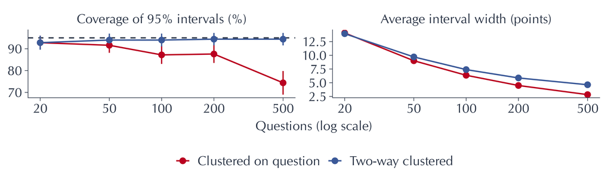

- Question-only clustering treats the 20 annotators as fixed. Coverage falls as questions are added.

[Cameron, Gelbach & Miller (2011), *Robust Inference With Multiway Clustering*, JBES 29(2).](https://doi.org/10.1198/jbes.2010.07136)

## Small samples break the normal approximation

$$\text{Wald: }\ \hat p\pm z\sqrt{\frac{\hat p(1-\hat p)}{N}},\qquad
\text{Wilson: }\ \Big\{p:\ |\hat p-p|\le z\sqrt{\frac{p(1-p)}{N}}\Big\}.$$

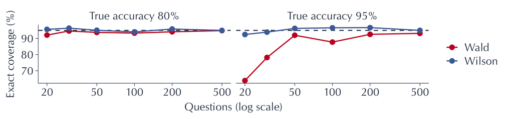

- $\hat p=x/N$, $z=1.96$. Wald plugs in $\hat p$, so 20 of 20 gives $[1,1]$. Wilson uses each candidate $p$.
- 95% accuracy, 20 questions: Wald covers 64%, Wilson 92%.

[Bowyer, Aitchison & Ivanova (2025), ICML.](https://arxiv.org/abs/2503.01747) [Wilson (1927), JASA 22(158).](https://doi.org/10.1080/01621459.1927.10502953)

## Benchmark scores depend on the questions

- A benchmark score averages over the questions its authors chose.
  - Its SE assumes they are a random sample from the population you care about.
- **Ailem et al.:** model performance is correlated across prompts.
  - Correlations track semantic similarity and shared failure points.
  - Accounting for them changes model rankings on major benchmarks.
- **Perlitz et al.:** HELM rankings shift with benchmark design choices.
  - Removing one low-ranked model can change the leader.
- **In your PAP:**
  - define the question population and how questions are drawn from it
  - cluster where questions arrive in groups
  - report the effect by topic as a secondary analysis.

[Ailem, Marazopoulou, Siska & Bono (2024), *Examining the Robustness of LLM Evaluation to the Distributional Assumptions of Benchmarks*, ACL.](https://aclanthology.org/2024.acl-long.560/) [Perlitz et al. (2024), *Efficient Benchmarking (of Language Models)*, NAACL.](https://arxiv.org/abs/2308.11696)

## Or is a benchmark just a fixed exam?

- An error bar asks how the score would move with a fresh draw of questions.
- A benchmark’s questions were chosen, curated, and frozen.
  - There is no population they were drawn from, so the error bar describes an imagined resampling.
- **Recht:** benchmarks work as a *shared competition*. Everyone takes the same exam, and results are reproducible.
- **Recht et al.:** a new ImageNet test set, built the same way, cost 11–14 points of accuracy.
  - That drop is far outside any error bar on the original test set.
  - The *ranking of models* was almost exactly preserved.
- Uncertainty still matters because deployment is a kind of replication.

[Recht (2025), *Standard error of what now?*, arg min.](https://www.argmin.net/p/standard-error-of-what-now) [Recht (2025), *Benchmarking our benchmarks*, arg min.](https://www.argmin.net/p/benchmarking-our-benchmarks) [Recht, Roelofs, Schmidt & Shankar (2019), *Do ImageNet Classifiers Generalize to ImageNet?*, ICML.](https://arxiv.org/abs/1902.10811)

## Standard errors that match the design

- The standard error must treat as independent exactly the units the design sampled or assigned independently.
- Repeated runs share a question, so **cluster** on the question. The **design effect** says how much call-level SEs understate, and it grows with more runs.
- **Pairs and blocks** are compared within, so their SEs drop the shared variation.
- Sampled questions and sampled annotators are **crossed**. **Two-way clustering** counts both, and the smaller sample caps precision.
- With few units the normal approximation fails. Use **small-sample intervals**.

# Covariates buy precision

## Use what you know before the experiment

- Before the study runs, you often know something about each question: its topic, how hard it was in a pilot.
- Retrieval cannot change that information, because it was recorded first.
- Using it in the analysis sharpens the comparison and leaves the target the same.
- This section shows how to use it.

## The Lin estimator: adjust with interactions

- **Freedman (2008):** adding covariates to the regression can reduce precision, and its usual SEs can be wrong.
  - The problem arises when treatment changes how covariates relate to the outcome.
- **Lin (2013):** center the covariate and interact it with treatment.

$$Y_i=\alpha+\tau Z_i+\beta(X_i-\bar X)+\gamma Z_i(X_i-\bar X)+\varepsilon_i.$$

- $\hat\tau$ estimates the average effect.
- **HC2 SE:** the sandwich with meat $\sum_i \mathbf x_i\mathbf x_i'\hat\varepsilon_i^2/(1-h_{ii})$; $\mathbf x_i$ is row $i$ of the regression, $h_{ii}$ its leverage.
- In large samples it is at least as precise as the difference in means.

```r
lm_lin(Y ~ Z, covariates = ~ pretest, data = study)
```

Freedman (2008), *On Regression Adjustments to Experimental Data*, Advances in Applied Mathematics 40(2). [Lin (2013), *Agnostic Notes on Regression Adjustments to Experimental Data*, Annals of Applied Statistics 7(1).](https://arxiv.org/abs/1208.2301) [MacKinnon & White (1985), *Some Heteroskedasticity-Consistent Covariance Matrix Estimators with Improved Finite Sample Properties*, J. Econometrics 29(3).](https://ideas.repec.org/a/eee/econom/v29y1985i3p305-325.html)

## Simulation: Lin adjustment narrows intervals

- **Covariate:** a pretreatment difficulty score for each of the 100 questions.
  - It explains 0% or 80% of the variation across questions.

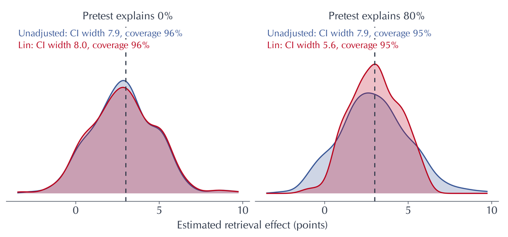

- Coverage stays near 95%. Width shrinks when the covariate predicts.

## Covariates are fixed before outcomes are seen

- **Pretreatment:** measured before assignment, so treatment cannot change it.
  - A pilot difficulty score, question topic, a student’s baseline quiz score.
- **Post-treatment:** answer length, number of retrieval calls, time spent with the tutor.
  - Adjusting for these biases the effect estimate.
- Choose covariates the way you chose blocks: by what predicts the outcome.
- Name them in the PAP, with the estimator.
  - Trying several sets and reporting the best gives intervals that are too narrow.
- Blocked designs can adjust too: block indicators as covariates.

Gerber & Green (2012), *Field Experiments*, ch. 4. [Lin (2013), *Agnostic Notes on Regression Adjustments to Experimental Data*, Annals of Applied Statistics 7(1).](https://arxiv.org/abs/1208.2301)

## AI predictions as covariates

- Before the experiment, a model can predict each question’s score.
  - Ask an LLM how hard the question is, or score a cheap model’s answer.
- **Arbour et al.:** add the prediction as a covariate in the Lin regression.

```r
lm_lin(Y ~ Z, covariates = ~ pretest + ai_prediction, data = study)
```

- Randomization keeps the estimate unbiased however poor the prediction is.
  - A useless prediction gets a coefficient near zero: the difference in means returns.
  - A good prediction narrows the interval.
- The prediction must use only pretreatment inputs, such as the question text.

[Arbour, Ben-Michael, Feller, Lal & Yuan (2026), *AI-Assisted Variance Reduction in Randomized Experiments*.](https://arxiv.org/abs/2606.08853)

## Covariate adjustment summary

- **Covariate adjustment** buys precision. Randomization already provides unbiasedness.
- The **Lin estimator**, with treatment interactions and robust SEs, is at least as precise as the difference in means in large samples.
- The gain depends on how well the covariate predicts the outcome. A useless covariate costs almost nothing.
- Only **pretreatment** covariates qualify, named in the PAP before outcomes are seen. **AI predictions** built from pretreatment inputs count.

# Measured outcomes add uncertainty

## What if the scores themselves are off?

- So far we have trusted the score each answer received.
- AI judges often do some of the scoring; they make mistakes.
- Some mistakes only add noise. Others push the result in one direction.
- This section shows how a small set of human ratings lets you check the judge and correct for it.

## LLM-judged outcomes are measured with error

- **Human score** $H_i$: the PAP’s outcome. **Judge score** $J_i$: the LLM judge’s score.

$$J_i=H_i+\delta Z_i+u_i.$$

- $u_i$: noise independent of treatment. It widens the interval.
- $\delta$: error that depends on treatment. Retrieval answers cite sources; the judge rewards citations.
- The difference in means on $J$ estimates $\tau+\delta$.
  - Its SE is correct for the effect on the judge’s score.
  - More questions shrink the interval around $\tau+\delta$, so coverage of $\tau$ falls as $N$ grows.
- **Knox et al.:** only a held-out sample of true labels identifies the proxy’s error.
- **Egami et al.:** use those true labels to calibrate how the judge’s labels enter the estimate.

[Egami, Hinck, Stewart & Wei (2023), *Using Imperfect Surrogates for Downstream Inference*, NeurIPS.](https://arxiv.org/abs/2306.04746) [Knox, Lucas & Cho (2022), *Testing Causal Theories with Learned Proxies*, Annual Review of Political Science.](https://doi.org/10.1146/annurev-polisci-051120-111443)

## Correct the judge with some human labels

- The judge scores all $N$ answers. Humans score a random sample: $R_i=1$ with known probability $\pi$, set independently of $Z_i$.
- **Design-based supervised learning (DSL)** pseudo-outcome (Egami et al.):

$$\tilde Y_i=J_i+\frac{R_i}{\pi}\big(H_i-J_i\big),\qquad \hat\tau=\bar{\tilde Y}_1-\bar{\tilde Y}_0.$$

- $E[\tilde Y_i\mid H_i,J_i]=H_i$: the correction removes $\delta$ and all other judge error.
- Neyman SE on $\tilde Y$. In one arm with $N$ answers, $n=\pi N$ of them human-labeled:

$$V\big(\bar{\tilde Y}\big)=\frac{V(H_i)}{N}+\Big(\frac1n-\frac1N\Big)E\big[(H_i-J_i)^2\big].$$

- Human labels alone: $V(H_i)$ replaces $E[(H_i-J_i)^2]$.
  - The judge helps when its mean squared error is below $V(H_i)$.

[Egami, Hinck, Stewart & Wei (2023), *Using Imperfect Surrogates for Downstream Inference*, NeurIPS, eq. 4.](https://arxiv.org/abs/2306.04746)

## Prediction-powered inference tunes a weight

- **PPI (Boyeau et al.):** $N$ judge scores, $n$ human labels, and a weight $\lambda$ on the judge:

$$\hat\mu=\frac{\lambda}{N}\sum_{i=1}^{N}J_i+\frac1n\sum_{i:R_i=1}\big(H_i-\lambda J_i\big).$$

- $\lambda=1$ is the DSL estimate with $\pi=n/N$.
- $\lambda=0$ uses the human labels alone.
- **PPI++** picks $\lambda$ to minimize the variance, so the estimate is at least as precise as human labels alone.
- A poor judge makes $E[(H_i-J_i)^2]$ larger than $V(H_i)$. Then $\lambda=1$ is less precise than ignoring the judge.
- For a treatment effect, apply the estimate in each arm and take the difference.

[Boyeau, Angelopoulos, Yosef, Malik & Jordan (2024), *AutoEval Done Right*, eq. 4.](https://arxiv.org/abs/2403.07008)

## Simulation: judge-only versus corrected intervals

- 1,000 questions; the judge scores all and adds $\delta=2$ to retrieval answers. Humans score a random 5–50%.

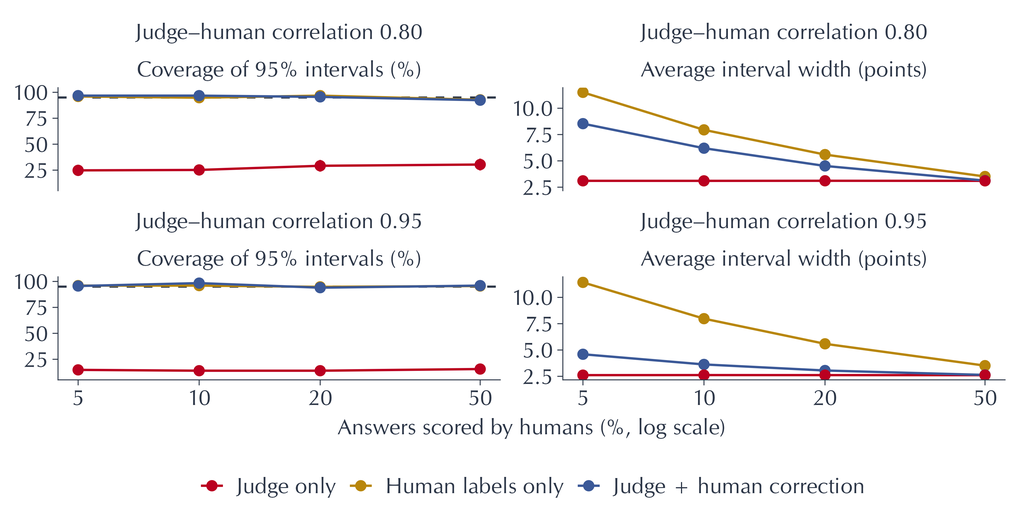

- Judge-only intervals mostly miss. The more accurate judge covers less: a narrower interval around $\tau+\delta$.
- Corrected intervals cover. With the 0.95 judge, 10% human labels match the width of 50% labeled by hand.

## Correcting judge-scored outcomes

- An LLM judge is a **surrogate** for the human score. Judge-only intervals are valid for the effect on the judge’s score.
- **Differential error**, where the judge favors one arm, biases the estimate. More questions make the interval more confidently wrong.
- A **random sample of human labels** with known probability identifies the judge’s error. **DSL** and **PPI** use it to correct the estimate.
- The corrected interval includes the labeling uncertainty. A more accurate judge needs fewer human labels for the same precision.

# Workshop preparation

## Plan for missing outcomes and many tests

Missing outcomes

- Refusals, API errors, timeouts, users who stop.
- Give every assigned unit an outcome: a refusal or failed call scores as a failure.
  - Then analyze everyone as assigned.
- Dropping them compares different subsets if treatment changes who goes missing.
- Fix the retry rule in advance. Report missingness by arm.

Many tests

- $k$ independent tests at 5%: the chance of at least one false positive is $1-0.95^k$, or **40%** for $k=10$.
- Name one primary outcome. Label the rest secondary or exploratory.
- For a family of primary tests, adjust the p-values:
  - **Holm:** familywise error rate.
  - **Benjamini–Hochberg:** false discovery rate.

Missing data: session 8. Many outcomes and summary indices: session 10. [Lin & Green (2016), *Standard Operating Procedures: A Safety Net for Pre-Analysis Plans*, PS 49(3).](https://www.stat.berkeley.edu/~winston/sop-safety-net.pdf)

## Bring your analysis plan to the workshop

- **Estimand:** the effect on which population of questions, users, or annotators, measured on which outcome.
- **Estimator:** difference in means, blocked or paired, or Lin with named pretreatment covariates.
- **Standard error:** clustered where sampling or assignment groups units; two-way if annotators are sampled.
- **Interval:** with few questions or clusters, a $t$ interval on the CR2 SE or randomization inference. For binary accuracy near 0 or 1, Wilson.
- **Judge-scored outcomes:** the fraction humans label at random, and the correction (DSL or PPI++).
- The workshop also covers missing data (refusals, users who disengage), and multiple comparisons.

Your reflection should trace out a step-by-step analytical recipe that you will follow over all relevant components.